# Patel et al. 2024 revision, Nanopore analysis

Read packages and methylation utilities:

```r
source("R/methylation_R_utils.R")
```

[output not shown]

Read the BSmoothed data in for GP5d WT and DNMTi+HDACi.

```r
# gp5d_meth <- read.bismark("/data/kzkarttu/nanopore/GP5D/methylation/methylation_calls.GP5D.raw.cpg.mfreq.txt.gz")
# gp5d_inh_meth <- read.modkit("/data/kzkarttu/projects/Patel_2024_revision/data/Nanopore/GP5d_DNMTi_HDACi/methylation/GP5d_DNMTi_HDACi_bedMethyl_no_GCG.bed.gz")
# gp5d_meth_comb <- bsseq::combine(gp5d_meth, gp5d_inh_meth)

# gp5d_meth_comb_smooth <- BSmooth(gp5d_meth_comb, BPPARAM = p)
# saveRDS(gp5d_meth_comb_smooth, "data/bsmooth/GP5d_WT_inh_CpG_bsmoothed.rds")

gp5d_meth_comb_smooth <- readRDS("data/bsmooth/GP5d_WT_inh_CpG_bsmoothed.rds")
ltr12c_loci <- read_tsv("data/LTR12C/LTR12C_DNMT_HDAC_Up_bothstrand_GP5d.bed", col_names = c("seqnames", "start", "end", "name", "width", "strand"))
```

Tabulate methylation per each LTR12C locus in GP5d WT and GP5d DNMTi+HDACi.

| seqnames | start | end | name | width | strand | GP5d_WT | GP5d_inh |
| --- | --- | --- | --- | --- | --- | --- | --- |
| chr1 | 1017170 | 1018876 | LTR12C | 1706 | - | 0.7759625 | 0.6006668 |
| chr1 | 1017170 | 1018876 | LTR12C | 1706 | - | 0.7753036 | 0.5987101 |
| chr1 | 1017170 | 1018876 | LTR12C | 1706 | - | 0.7751395 | 0.5982183 |
| chr1 | 1017170 | 1018876 | LTR12C | 1706 | - | 0.7731897 | 0.5922514 |
| chr1 | 1017170 | 1018876 | LTR12C | 1706 | - | 0.7727880 | 0.5909967 |
| chr1 | 1017170 | 1018876 | LTR12C | 1706 | - | 0.7719096 | 0.5882280 |
| chr1 | 1017170 | 1018876 | LTR12C | 1706 | - | 0.7706452 | 0.5841916 |
| chr1 | 1017170 | 1018876 | LTR12C | 1706 | - | 0.7698628 | 0.5816713 |
| chr1 | 1017170 | 1018876 | LTR12C | 1706 | - | 0.7679328 | 0.5754160 |
| chr1 | 1017170 | 1018876 | LTR12C | 1706 | - | 0.7673230 | 0.5734375 |

[output cut: 990 more lines]

[output not shown]

[output cut: 990 more lines]

```r
flank <- 1000

ltr12c_meth_loci <- bind_rows(mclapply(1:nrow(ltr12c_loci), mc.cores = 40, function(i) {
  coords <- bsseq::subsetByOverlaps(gp5d_meth_comb_smooth, GRanges(ltr12c_loci[i, ]) + flank)
  cov <- getCoverage(coords, type = "Cov", what = "perBase")
  m <- getCoverage(coords, type = "M", what = "perBase")

  bind_rows(
    ltr12c_loci[i, ] %>%
      bind_cols(., as_tibble(granges(coords)) %>% dplyr::select(-width, -strand, -end) %>% setNames(paste0("cpg_", names(.)))) %>%
      mutate(
        cov = cov[, 1],
        m = m[, 1]
      ),
    ltr12c_loci[i, ] %>%
      bind_cols(., as_tibble(granges(coords)) %>% dplyr::select(-width, -strand, -end) %>% setNames(paste0("cpg_", names(.)))) %>%
      mutate(
        cov = cov[, 2],
        m = m[, 2]
      ),
    .id = "cells"
  )
}))

ltr12c_meth_loci_all <- ltr12c_meth_loci %>%
  mutate(
    unmeth = cov - m,
    freq = m / (m + unmeth),
    flk = case_when(
      cpg_start < start ~ "flk_up",
      cpg_start > end ~ "flk_dn",
      cpg_start >= start & cpg_start <= end ~ "int"
    ),
    dist = case_when(
      flk == "int" ~ round((cpg_start - start) / (end - start), 3),
      flk == "flk_up" ~ round((cpg_start - start) / flank / 2, 3),
      flk == "flk_dn" ~ round(1 + (cpg_start - end) / flank / 2, 3),
    ),
  ) %>%
  na.omit() %>%
  filter(cov >= 3)

ltr12c_meth_loci_list <- ltr12c_meth_loci_all %>%
  group_by(cells) %>%
  group_split(.keep = F)

ltr12c_meth_loci_ag <- lapply(1:2, function(i) {
  ltr12c_meth_loci_list[[i]] %>%
    group_by(dist) %>%
    dplyr::summarize(
      freq = mean(freq, na.rm = T),
    )
})

win <- .025

suppressWarnings(
ltr12c_meth_loci_ag_rollmeans <- lapply(1:2, function(i) {
  roll_range <- seq(
    from = min(ltr12c_meth_loci_ag[[i]]$dist) + win / 2,
    to = max(ltr12c_meth_loci_ag[[i]]$dist) - win / 2, by = .001
  )

  rollmeans <- numeric()

  for (center in roll_range) {
    dat_win <- ltr12c_meth_loci_ag[[i]][which(ltr12c_meth_loci_ag[[i]]$dist >= center - win &
      ltr12c_meth_loci_ag[[i]]$dist <= center + win), ]
    rollmean <- mean(dat_win$freq)
    rollmeans <- c(rollmeans, rollmean)
  }
  tibble(roll_range, rollmeans)
}))
```

Plot aggregated methylation difference in both GP5d cell lines, in a window around the center of all the 500 LTR12C peaks.

| cells | roll_range | rollmeans |
| --- | --- | --- |
| GP5d WT | -0.4875 | 0.6619829 |
| GP5d WT | -0.4865 | 0.6624428 |
| GP5d WT | -0.4855 | 0.6625484 |
| GP5d WT | -0.4845 | 0.6623762 |
| GP5d WT | -0.4835 | 0.6638011 |
| GP5d WT | -0.4825 | 0.6584230 |
| GP5d WT | -0.4815 | 0.6661861 |
| GP5d WT | -0.4805 | 0.6634939 |
| GP5d WT | -0.4795 | 0.6660326 |
| GP5d WT | -0.4785 | 0.6688576 |

[output cut: 990 more lines]

[figure not shown]

Aggregated methylation line plot over all 500 LTR12C loci, not normalized for LTR12C length

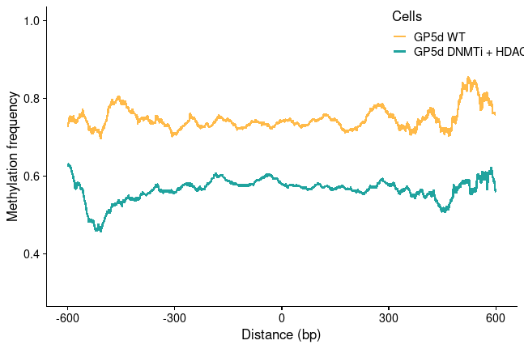

```r
ggplot(plot_meth, aes(x = dist, y = freq, color = factor(line, ordered = T, levels = c("GP5d WT", "GP5d DNMTi + HDACi")))) +
  geom_line(size = 1) +
  xlab("Distance (bp)") +
  ylab("Methylation frequency") +
  scale_x_continuous(limits = c(-600, 600)) +
  scale_y_continuous(limits = c(0.3, 1)) +
  scale_color_manual(values = c("#ffba49", "#20a39e")) +
  guides(color = guide_legend(title = "Cells")) +
  theme(legend.position = c(.88, .91))
```

Comparing the extent of the difference in methylation between the two GP5d conditions, the table is sorted by the largest mean difference in methylation and the smallest adjusted p-value. “One” in this table means the GP5d WT and “Two” is GP5d DNMTi+HDACi.

```r
gp5d_meth_comb_compare <- compareRegions(gp5d_meth_comb_smooth, 1, 2, GRanges(ltr12c_loci))
```

```
subsetting data in region
getting indexes of data in region
comparing
```

```r
gp5d_meth_comb_compare %>%
  arrange(meandiff, adjusted.pval)
```

| chr | start | end | idxStart | idxEnd | cov_one | cov_two | meth_one | meth_two | average_one | average_two | meandiff | maxdiff | direction | p.value | adjusted.pval | width | sig |
| --- | --- | --- | --- | --- | --- | --- | --- | --- | --- | --- | --- | --- | --- | --- | --- | --- | --- |
| chr6 | 19806148 | 19807531 | 10429 | 10469 | 107 | 215 | 102 | 83 | 0.95678375 | 0.36304175 | -0.593741999 | -0.69574297 | down | 1.088873e-25 | 3.202567e-24 | 1384 | sig |
| chr12 | 131227629 | 131229312 | 18498 | 18548 | 158 | 439 | 132 | 109 | 0.80524895 | 0.23363359 | -0.571615360 | -0.60863883 | down | 5.531855e-39 | 1.382964e-36 | 1684 | sig |
| chr19 | 33036456 | 33037857 | 23425 | 23479 | 67 | 430 | 56 | 167 | 0.85363229 | 0.36073906 | -0.492893224 | -0.63150556 | down | 3.024648e-12 | 1.326600e-11 | 1402 | sig |
| chr17 | 8717046 | 8718632 | 21839 | 21892 | 230 | 440 | 166 | 112 | 0.73745871 | 0.25873204 | -0.478726670 | -0.57686271 | down | 9.540592e-32 | 7.950493e-30 | 1587 | sig |
| chr15 | 90825338 | 90826830 | 21063 | 21120 | 263 | 667 | 212 | 212 | 0.78922075 | 0.31601382 | -0.473206929 | -0.52696467 | down | 7.117559e-43 | 3.558780e-40 | 1493 | sig |
| chr6 | 31195281 | 31196824 | 10875 | 10928 | 224 | 490 | 179 | 172 | 0.79515028 | 0.34514744 | -0.450002838 | -0.66089366 | down | 6.434039e-30 | 4.021274e-28 | 1544 | sig |
| chr17 | 68207675 | 68209028 | 22405 | 22454 | 229 | 402 | 201 | 194 | 0.90246286 | 0.46968208 | -0.432780782 | -0.52961792 | down | 5.492148e-25 | 1.525597e-23 | 1354 | sig |
| chr12 | 71377134 | 71377608 | 17917 | 17935 | 117 | 101 | 96 | 35 | 0.81958596 | 0.38973241 | -0.429853551 | -0.46471089 | down | 5.568345e-13 | 2.812295e-12 | 475 | sig |
| chr3 | 165917731 | 165919011 | 5443 | 5492 | 187 | 401 | 170 | 194 | 0.90726648 | 0.47842099 | -0.428845494 | -0.52475607 | down | 6.043492e-26 | 2.014497e-24 | 1281 | sig |
| chr9 | 89680905 | 89682497 | 14905 | 14978 | 261 | 693 | 227 | 313 | 0.85421658 | 0.42806931 | -0.426147266 | -0.56574279 | down | 3.090540e-34 | 5.150900e-32 | 1593 | sig |

[output cut: 490 more lines]

| chr | start | end | idxStart | idxEnd | cov_one | cov_two | meth_one | meth_two | average_one | average_two | meandiff | maxdiff | direction | p.value | adjusted.pval | width | sig | lab |
| --- | --- | --- | --- | --- | --- | --- | --- | --- | --- | --- | --- | --- | --- | --- | --- | --- | --- | --- |
| chr1 | 1017170 | 1018876 | 1 | 54 | 443 | 860 | 318 | 535 | 0.74281329 | 0.62315130 | -0.119661986 | -0.22317985 | down | 3.276319e-04 | 5.135296e-04 | 1707 | Significant (-) | NA |
| chr1 | 2813099 | 2814487 | 55 | 103 | 241 | 355 | 108 | 129 | 0.49421622 | 0.36824805 | -0.125968174 | -0.30846924 | down | 2.344303e-02 | 2.952523e-02 | 1389 | Significant (-) | NA |
| chr1 | 11608569 | 11609920 | 104 | 157 | 325 | 1000 | 222 | 633 | 0.64908668 | 0.61938969 | -0.029696990 | -0.09162763 | down | 5.729227e-02 | 6.853143e-02 | 1352 | Insignificant | NA |
| chr1 | 13439101 | 13440398 | 158 | 207 | 258 | 457 | 207 | 237 | 0.74707890 | 0.48222396 | -0.264854940 | -0.33466225 | down | 1.237316e-14 | 8.966057e-14 | 1298 | Significant (-) | NA |
| chr1 | 14419528 | 14421085 | 208 | 270 | 152 | 651 | 106 | 335 | 0.66985134 | 0.48467977 | -0.185171572 | -0.28762845 | down | 2.680387e-05 | 4.803561e-05 | 1558 | Significant (-) | NA |
| chr1 | 29130245 | 29131642 | 271 | 320 | 241 | 603 | 183 | 352 | 0.76929044 | 0.57364565 | -0.195644797 | -0.24105504 | down | 8.101781e-07 | 1.709236e-06 | 1398 | Significant (-) | NA |
| chr1 | 37518069 | 37519559 | 321 | 378 | 298 | 646 | 215 | 414 | 0.73350137 | 0.63522069 | -0.098280672 | -0.23926267 | down | 8.574755e-03 | 1.146358e-02 | 1491 | Significant (-) | NA |
| chr1 | 54003217 | 54004787 | 379 | 429 | 294 | 630 | 233 | 462 | 0.76710191 | 0.72344723 | -0.043654688 | -0.16292170 | down | 3.053828e-02 | 3.779490e-02 | 1571 | Significant (-) | NA |
| chr1 | 59471948 | 59473492 | 430 | 492 | 200 | 733 | 161 | 514 | 0.78983969 | 0.69463893 | -0.095200769 | -0.20411871 | down | 1.966488e-03 | 2.801265e-03 | 1545 | Significant (-) | NA |
| chr1 | 59968802 | 59970229 | 493 | 549 | 360 | 528 | 289 | 346 | 0.78149345 | 0.64648862 | -0.135004822 | -0.17746789 | down | 9.180111e-07 | 1.920525e-06 | 1428 | Significant (-) | NA |

[output cut: 490 more lines]

#### Paired boxplot of the individual differences in methylation at upregulated GP5d DNMTi + HDACi LTR12C elements.

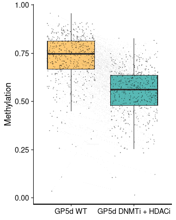

#### Same plot as above but for all downregulated TE subfamilies in GP5d DNMTi + HDACi.

```r
GP5d_inh_all_down <- read_tsv("data/TEs/GP5d_DNMTi_HDACi_Downregulated.bed", col_names = c("seqnames", "start", "end", "name", "family", "class"))
gp5d_meth_comb_compare_all_down <- compareRegions(gp5d_meth_comb_smooth, 1, 2, GRanges(GP5d_inh_all_down))
```

```
subsetting data in region
getting indexes of data in region
comparing
```

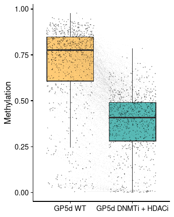

```r
gp5d_meth_comb_compare_all_down %>%
  pivot_longer(cols = c(average_one, average_two)) %>%
  mutate(
    name = factor(if_else(name == "average_one", "GP5d WT", "GP5d DNMTi + HDACi"), ordered = T, levels = c("GP5d WT", "GP5d DNMTi + HDACi")),
    id = rep(1:(1570 / 2), each = 2, length.out = 1570)
  ) %>% # Making an ID column for paired boxplot
  ggplot(aes(x = name, y = value, fill = name)) +
  geom_boxplot(aes(group = name), outlier.shape = NA, alpha = .75) +
  # geom_jitter(width = 0.3, size = .2, seed = 1234) +
  geom_point(size = .2, alpha = .25, position = position_jitter(seed = 1234, width = .38)) +
  geom_line(aes(group = factor(id)), size = .05, alpha = .05, position = position_jitter(seed = 1234, width = .38)) +
  scale_fill_manual(values = c("#ffba49", "#20a39e")) +
  theme(axis.title.x = element_blank(),
        legend.position = "none") +
  ylab("Methylation")
```

```r
# ggsave("figures/240703_GP5d_wt_inh_all_down_methylation_boxplot.pdf", width = 4, height = 5)
```

#### Same plot as above but for all UPregulated TE subfamilies in GP5d DNMTi + HDACi.

```r
GP5d_inh_all_up <- read_tsv("data/TEs/GP5d_DNMTi_HDACi_Upregulated.bed", col_names = c("seqnames", "start", "end", "name", "family", "class"))
gp5d_meth_comb_compare_all_up <- compareRegions(gp5d_meth_comb_smooth, 1, 2, GRanges(GP5d_inh_all_up))
```

```
subsetting data in region
getting indexes of data in region
comparing
```

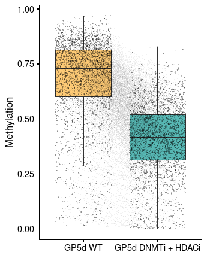

```r
gp5d_meth_comb_compare_all_up %>%
  pivot_longer(cols = c(average_one, average_two)) %>%
  mutate(
    name = factor(if_else(name == "average_one", "GP5d WT", "GP5d DNMTi + HDACi"), ordered = T, levels = c("GP5d WT", "GP5d DNMTi + HDACi")),
    id = rep(1:(nrow(.) / 2), each = 2, length.out = nrow(.))
  ) %>% # Making an ID column for paired boxplot
  ggplot(aes(x = name, y = value, fill = name)) +
  geom_boxplot(aes(group = name), outlier.shape = NA, alpha = .75) +
  # geom_jitter(width = 0.3, size = .2, seed = 1234) +
  geom_point(size = .2, alpha = .25, position = position_jitter(seed = 1234, width = .38)) +
  geom_line(aes(group = factor(id)), size = .05, alpha = .05, position = position_jitter(seed = 1234, width = .38)) +
  scale_fill_manual(values = c("#ffba49", "#20a39e")) +
  theme(axis.title.x = element_blank(),
        legend.position = "none") +
  ylab("Methylation")
```

```r
# ggsave("figures/240703_GP5d_wt_inh_all_up_methylation_boxplot.pdf", width = 4, height = 5)
GP5d_inh_all_up <- read_tsv("data/TEs/GP5d_DNMTi_HDACi_Upregulated.bed", col_names = c("seqnames", "start", "end", "name", "family", "class"))
gp5d_meth_comb_compare_all_up <- compareRegions(gp5d_meth_comb_smooth, 1, 2, GRanges(GP5d_inh_all_up))
```

```
subsetting data in region
getting indexes of data in region
comparing
```

[output not shown]

[output cut: 990 more lines]